# (Loan Data from Prosper Exploration)

## by (Mohamed Mamdouh Aly)

## Investigation Overview

> In this investigation we want to look at the relationship between the features in loans dataset from the columns that we think it has a relationships to each others for example (loans amount, IncomeRange, IncomeVerifiable, Investors, etc), also we are going to find some answers about the data features and find the affect of each feature to the other features through making multi types of visualizations to understand more.

## Dataset Overview

> The data contains data about loans it's around 113937 rows and 81 columns. we have many important columns (LoanStatus, BorrowerRate, ListingCategory (numeric), IncomeRange, IncomeVerifiable, StatedMonthlyIncome) and the more, the data shows the characteristics of each loan some information about the loan, some information about the borrower and information about the investors.

## Distribution of Loan Original Amount

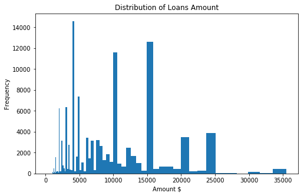

```python
plt.figure(figsize=[8, 5])

log_binsize = 0.025
bins = 10 ** np.arange(2.4, np.log10(df['LoanOriginalAmount'].max())+log_binsize, log_binsize)
df['LoanOriginalAmount'].hist(bins=bins, grid=False);
plt.xlabel('Amount $');
plt.ylabel('Frequency');
plt.title("Distribution of Loans Amount");
```

## Distribution of Stated Monthly Income

> For the Distribution of Stated Monthly Income, we can see that we have found an outlier in the distribution with Stated Monthly Income 1750000 that is really big number comparing to the all data so we have filtered it out, to see the real distribution more clear. Form the distribution of Stated Monthly Income we can notice that the average of monthly income is around 5000 and that which means the people who get paid around 5000 has higher percentage to take loans.

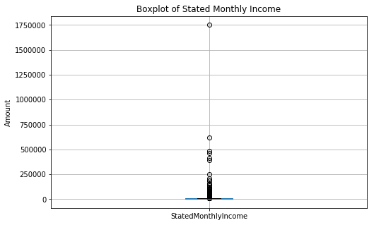

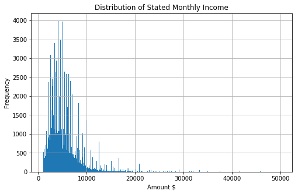

```python
binsize = 100
bins = np.arange(1000, 50000 + binsize, binsize)

plt.figure(figsize=[8, 5]);
df.boxplot(column=['StatedMonthlyIncome']);
plt.ylabel('Amount');
plt.title("Boxplot of Stated Monthly Income");
plt.show();

plt.figure(figsize=[8, 5]);
df.query("StatedMonthlyIncome < 150000")['StatedMonthlyIncome'].hist(bins=bins);
plt.ylabel('Frequency');
plt.xlabel('Amount $');
plt.title("Distribution of Stated Monthly Income");
plt.show()
```

## Relationship between LoanOriginalAmount and Investors

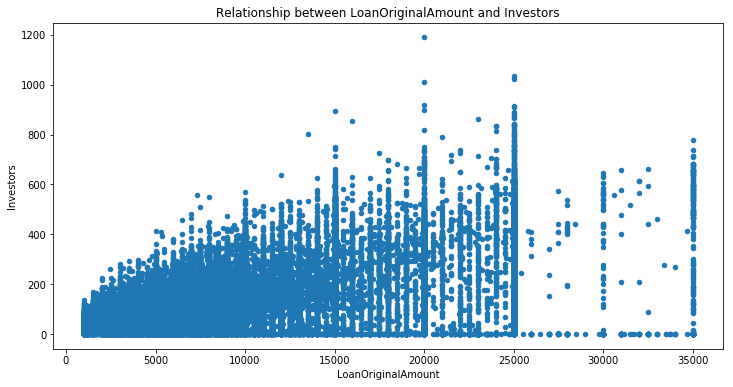

```python
df.plot("LoanOriginalAmount", "Investors", kind='scatter', figsize=[12, 6]);
plt.title("Relationship between LoanOriginalAmount and Investors");
```